# Forecasting with Decomposition - New Home Sales

Chloé Winters

11/24/2024

# 1 Introduction

This assignment is going to focus on decomposing time series and forecasting with decomposing for new home sales in the United States.

# 2 Materials

## 2.1 Data Set

The time series used in this assignment is from the United States Census Bureau, the name of the time series is Annual Rate for New Single-family Houses Sold. The time series is contained to homes sold in the United States. The data spans 744 months from January of 1963 to December of 2024, however for this assignment, we will only be using the monthly data between January 2010 and December 2024.

## 2.2 Data Cleaning

Since the selected subset of the time series January 2010 to December 2024 has some dates that have not happened yet as of the completion of this assignment, we make sure to remove and months that are listed as “N/A” instead of a numerical value, and then convert the value column from character to numeric.

```r
url="https://ChloeWinters79.github.io/STA321/Data/USHomeSales.csv"
home.sales = read.csv(url, header = TRUE)
n.row = dim(home.sales)[1]
data.home.sales.0 = home.sales[(n.row-179):n.row, ]
data.home.sales = subset(data.home.sales.0, Value != "N/A")
data.home.sales$Value <- as.numeric(as.character(data.home.sales$Value))
```

Now that all the necessary data cleaning has been completed and we have a complete time series for our desired time range we can move forward with our analysis.

# 3 Methodology & Analysis

## 3.1 Defining the Time Series

To start the analysis we are going to graph the time series, this way we can see if it is linear, if there are any outliers we should be aware of, etc. Since this is time series consits of monthly data, to define the time series object a frequencey of 12 needs to be used to graph the data appropriately.

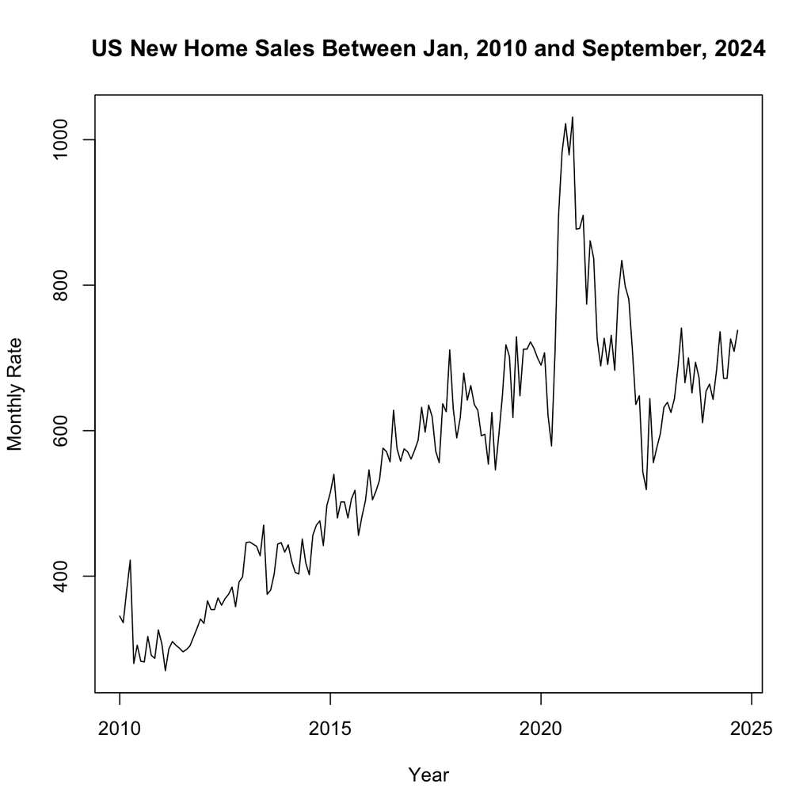

US New Home Sales Monthly Rate

```r
homesales.ts = ts(data.home.sales[,2], frequency = 12, start = c(2010, 1))
plot(homesales.ts,
     main="US New Home Sales Between Jan, 2010 and September, 2024",
     ylab="Monthly Rate",
     xlab="Year")
```

Looking at the time series graph, it appears to be quite linear. However, after 2020 we se a large spike that is followed by a large drop around 2022/2023. This large spike and drop is not consistent with the linear trend we see from 2010-2020, and it will be interesting to see how this trend progresses in the future and what 2020 - 2030 data will look like and if it will have a linear trend like 2010-2020 or if it will have high peaks and low drops and alternates over the years.

## 3.2 Forecasting with Decomposing

Now we are going to look at the classical decomposition method and compare that method to the STL method. Visual representations will be created for both of the methods so proper analysis and comparison can be conducted on the two methods to determine which one is the better method.

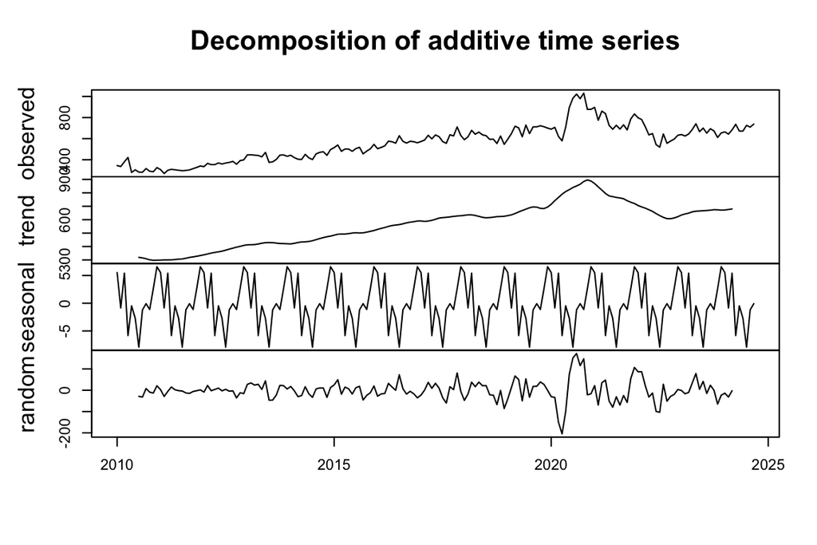

Classical decomposition of additive time series

```r
cls.homesales = decompose(homesales.ts)
par(mar=c(2,2,2,2))
plot(cls.homesales, xlab="")
```

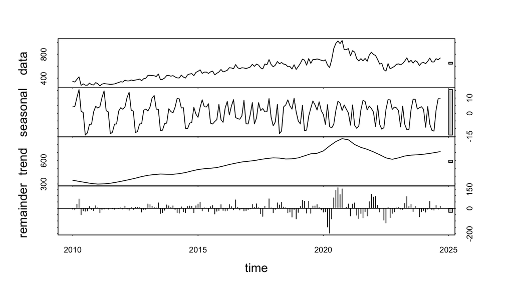

STL decomposition of additive time series

```r
stl.homesales=stl(homesales.ts, s.window = 12)
par(mar=c(2,2,2,2))
plot(stl.homesales)
```

After looking at the visual representations above, it is clear that the STL method works better than the classical decomposition of the method. This is due to the robustness associated with the LOESS component.

## 3.3 Training and Testing Data

Since the year 2024 is not complete and only has 9 observations instead of the usual 12, we will hold the last 9 periods of the data for testing. The remainder of the data will be used for training the forecast model.

To properly evaluate the effect of different data set sizes in training the time series, we will define different training data sets composed of different sizes. In this assignment those different training set sizes will be, 168, 132, 96, and 72. The same test test with size 9 will be used to calculate the predicition error for each of the 4 different training set sizes.

```r
ini.data = data.home.sales[,2]
n0 = length(ini.data)
train.data01 = data.home.sales[1:(n0-9), 2]
train.data02 = data.home.sales[37:(n0-9), 2]
train.data03 = data.home.sales[73:(n0-9), 2]
train.data04 = data.home.sales[97:(n0-9), 2]
## last 9 observations
test.data = data.home.sales[(n0-8):n0,2]
train01.ts = ts(train.data01, frequency = 12, start = c(2010, 1))
train02.ts = ts(train.data02, frequency = 12, start = c(2013, 1))
train03.ts = ts(train.data03, frequency = 12, start = c(2016, 1))
train04.ts = ts(train.data04, frequency = 12, start = c(2018, 1))
stl01 = stl(train01.ts, s.window = 12)
stl02 = stl(train02.ts, s.window = 12)
stl03 = stl(train03.ts, s.window = 12)
stl04 = stl(train04.ts, s.window = 12)
## Forecast with decomposing
fcst01 = forecast(stl01,h=9, method="naive")
fcst02 = forecast(stl02,h=9, method="naive")
fcst03 = forecast(stl03,h=9, method="naive")
fcst04 = forecast(stl04,h=9, method="naive")
```

```r
## To compare different errors, we will not use the percentage for MAPE
PE01=(test.data-fcst01$mean)/fcst01$mean
PE02=(test.data-fcst02$mean)/fcst02$mean
PE03=(test.data-fcst03$mean)/fcst03$mean
PE04=(test.data-fcst04$mean)/fcst04$mean
###
MAPE1 = mean(abs(PE01))
MAPE2 = mean(abs(PE02))
MAPE3 = mean(abs(PE03))
MAPE4 = mean(abs(PE04))
###
E1=test.data-fcst01$mean
E2=test.data-fcst02$mean
E3=test.data-fcst03$mean
E4=test.data-fcst04$mean
MSE1=mean(E1^2)
MSE2=mean(E2^2)
MSE3=mean(E3^2)
MSE4=mean(E4^2)
###
MSE=c(MSE1, MSE2, MSE3, MSE4)
MAPE=c(MAPE1, MAPE2, MAPE3, MAPE4)
accuracy=cbind(MSE=MSE, MAPE=MAPE)
row.names(accuracy)=c("n.168", "n.132", "n. 96", "n. 72")
kable(accuracy, caption="Error comparison between forecast results with different sample sizes")
```

Error comparison between forecast results with different sample sizes

|  | MSE | MAPE |
| --- | --- | --- |
| n.168 | 3120.275 | 0.0706637 |
| n.132 | 3189.463 | 0.0715776 |
| n. 96 | 3587.685 | 0.0778266 |
| n. 72 | 4113.795 | 0.0852863 |

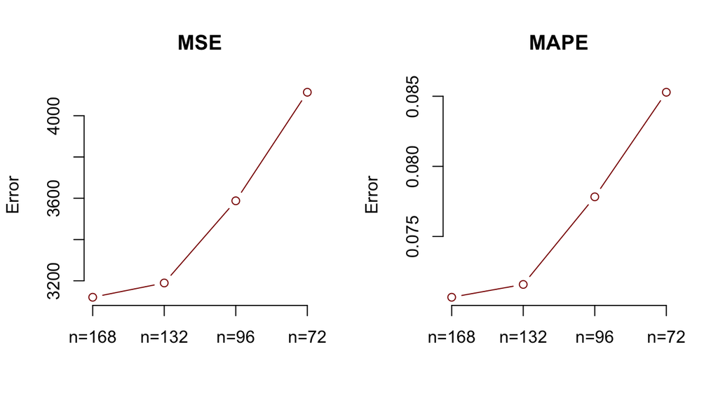

Comparing forecast errors

````r
par(mfrow=c(1,2))
plot(1:4, MSE, type="b", col="darkred", ylab="Error", xlab="",
     #ylim=c(0.4,.85),xlim = c(0.5,4.5),
     main="MSE", axes=FALSE)
labs=c("n=168", "n=132", "n=96", "n=72")
axis(1, at=1:4, label=labs)
axis(2)
legend(1.5, 0.63, c("MSE", "MAPE"), col=c("darkred","blue"), lty=1, bty="n", cex=0.7)
###
#```{r fig.align='center', fig.cap= "Comparing forecast errors", fig.width=5, fig.height=3.5}
plot(1:4, MAPE, type="b", col="darkred", ylab="Error", xlab="",
     #ylim=c(0.4,.85),xlim = c(0.5,4.5),
     main="MAPE", axes=FALSE)
labs=c("n=168", "n=132", "n=96", "n=72")
axis(1, at=1:4, label=labs)
axis(2)
````

There is not a huge jump from the 168 training size to the 132 size and we want to use the smaller training size when picking between two good options. While the training sizes 96 and 72 are smaller sizes they have significantly larger errors than the 132 and 168 training sizes so we do not want to use either of those models.

Additionally, it should be noted that the range for MSE is very large, much larger than one would expect. The MSE graph ranges from 3,200 to over 4,000, this is because we are dealing with observations in the 100s, and 1000s and squaring the differences. An important part of calculating mean square error is squaring. When dealing with observations that are much larger a difference of 50 or 75 can create an extremely large MSE. For example, if our forecasted value is 500 but the actual value is 575 we have a difference of 75,
$$75^2 = 5,625$$
which looks like an extremely high error margin when the highest observation is 1,031. When this happens and we are dealing with such large MSE error values we are advised to rely only the MAPE output in determining our best training set size, thankfully since the MSE and MAPE are visually matching we can be confident in our final decision to use the training set size of 132.

# 4 Results & Conclusion

While the STL method was the better method over the classical decomposition of the time series, it does not yield the best results. More work needs to be done to the model to help build it into a practical forecasting model. In the next assignment, we will look into using exponential smoothing to create the best version of the model so proper conclusions can be drawn from the time series model. This assignment is really just the first step in our time series model building and analysis and it will need to be continued before we can draw meaningful conclusions.

# 5 General Discussion

Since we still need to look into the exponential smoothing model and the analysis of that, in addition to how it impacts the training model there are not many proper conclusions to be drawn. In a professional setting where this is a report that would be handed to a company or superior, the exponential smoothing model would be conducted so the report could be properly finished. However, this is a class where we are still learning, not a professional business report, so there are limitations on the analysis that I can conduct.

In terms of the report so far, another thing that should still be discussed is the MSE range on this report. As mentioned earlier, the MSE range is quite large, and larger than the range of the observations reported in the data set. As talked about before, this can be expected when dealing with larger values, since the MSE of a forecast of 500 and and actual of 575 is different than a forecast of 5.00 and an actual of 5.75, even if the differences are proportionally the same in terms of the data set. Seeing errors in the 3000 to 4000 range can be confusing for those who do not fully understand statistics and understand why that is happening. It can make them thing that the models are doing a poor job in forecasting the actual values when they are actually doing a fine job. Due to the possible miss interpretation, it might be worthwhile to take the values in the data set and compress them into smaller values to bring down the MSE to make it more interpretable for readers. Dividing all the observations in the data set by 100 or 1000, would bring down the MSE range and hopefully make the data more understandable for readers. Since, this report was not finished and still had to go through exponential smoothing, I made the decision to not make that change at this time, however it is something to consider as I continue working on this report.